# HW3 Peer Assessment

# Background

The fishing industry uses numerous measurements to describe a specific fish. Our goal is to predict the weight of a fish based on a number of these measurements and determine if any of these measurements are insignificant in determining the weigh of a product. See below for the description of these measurments.

## Data Description

The data consists of the following variables:

1. **Weight**: weight of fish in g (numerical)
2. **Species**: species name of fish (categorical)
3. **Body.Height**: height of body of fish in cm (numerical)
4. **Total.Length**: length of fish from mouth to tail in cm (numerical)
5. **Diagonal.Length**: length of diagonal of main body of fish in cm (numerical)
6. **Height**: height of head of fish in cm (numerical)
7. **Width**: width of head of fish in cm (numerical)

## Read the data

```r
# Import library you may need
library(car)
# Read the data set
fishfull = read.csv("C:\\Users\\adri_\\Documents\\Gatech\\ISYE6414\\Homeworks\\3-Multiple_linear_regression_part 2\\Fish.csv",header=T, fileEncoding = 'UTF-8-BOM')
row.cnt = nrow(fishfull)
# Split the data into training and testing sets
fishtest = fishfull[(row.cnt-9):row.cnt,]
fish = fishfull[1:(row.cnt-10),]
```

*Please use fish as your data set for the following questions unless otherwise stated.*

# Question 1: Exploratory Data Analysis [10 points]

**(a) Create a box plot comparing the response variable, *Weight*, across the multiple *species*. Based on this box plot, does there appear to be a relationship between the predictor and the response?**

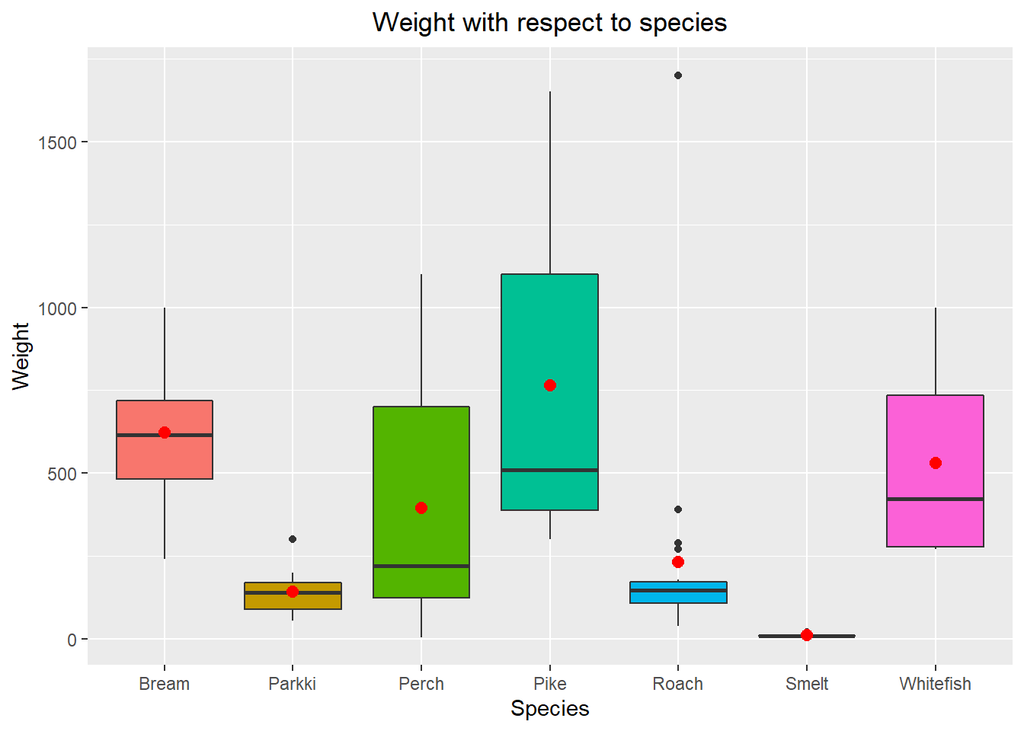

```r
library(ggplot2)

ggplot(fish, aes(
  x=Species, y=Weight, fill=Species)) + geom_boxplot(alpha = 3) +
  stat_summary(fun.y=mean, geom="point", shape=20, size=4, color="red", fill="red") +
  theme(legend.position = "none") + ggtitle("Weight with respect to species") +
  theme(plot.title = element_text(hjust = 0.5))
```

**Answer** Yes,there is a relationship between the weight and the species. The mean weight in Pike fishes is larger than the rest of the species. In contrast, Smelt, Roach and Parkki fishes have smaller mean weight than the rest of the species.

**(b) Create plots of the response, *Weight*, against each quantitative predictor, namely** Body.Height**,** Total.Length**,** Diagonal.Length**,** Height**, and** Width**. Describe the general trend of each plot. Are there any potential outliers?**

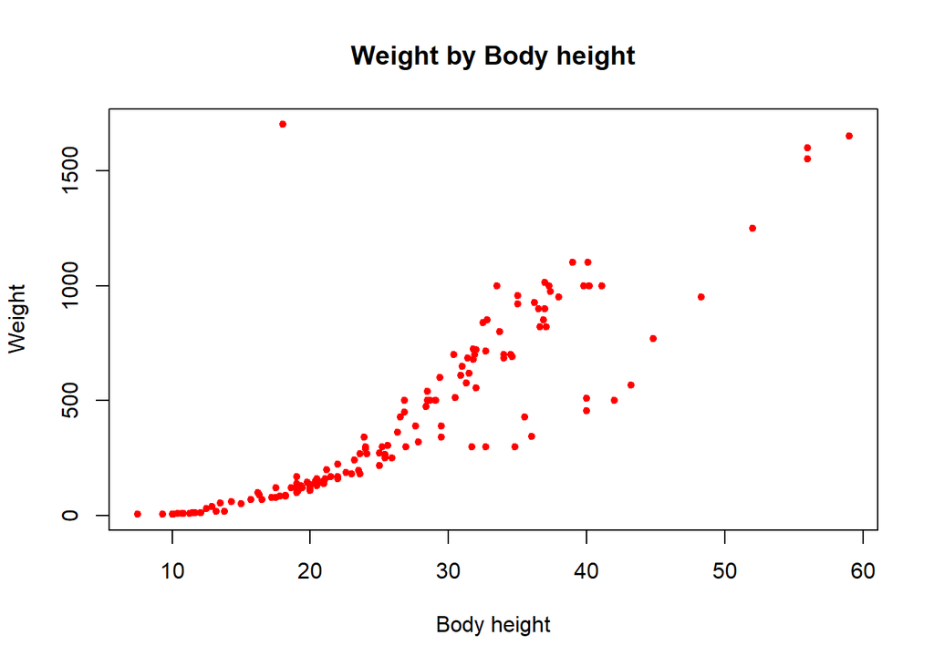

```r
#Weight is the response variable

plot(fish$Body.Height,fish$Weight,
     xlab="Body height",
     ylab="Weight",
     main="Weight by Body height",
     col = "red",
     pch=20)
```

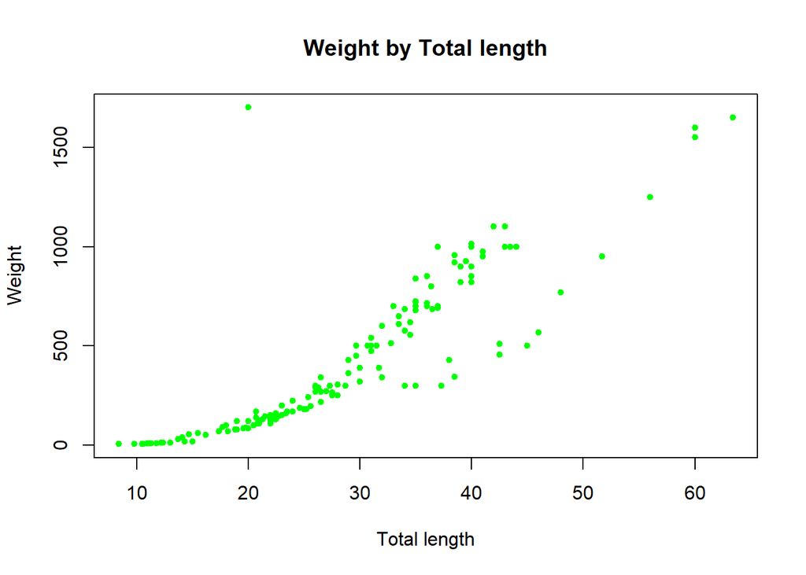

```r
plot(fish$Total.Length,fish$Weight,
     xlab="Total length",
     ylab="Weight",
     main="Weight by Total length",
     col = "green",
     pch=20)
```

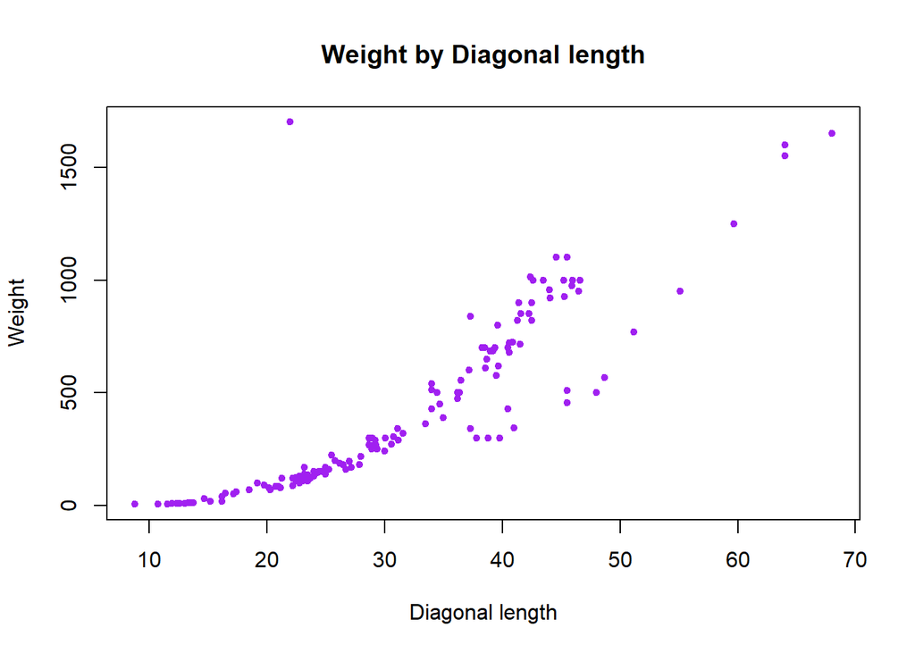

```r
plot(fish$Diagonal.Length,fish$Weight,
     xlab="Diagonal length",
     ylab="Weight",
     main="Weight by Diagonal length",
     col = "purple",
     pch=20)
```

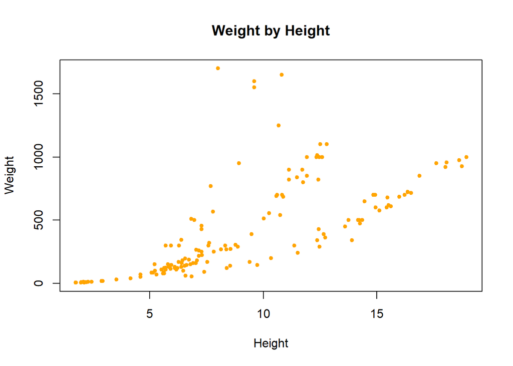

```r
plot(fish$Height,fish$Weight,
     xlab="Height",
     ylab="Weight",
     main="Weight by Height",
     col = "orange",
     pch=20)
```

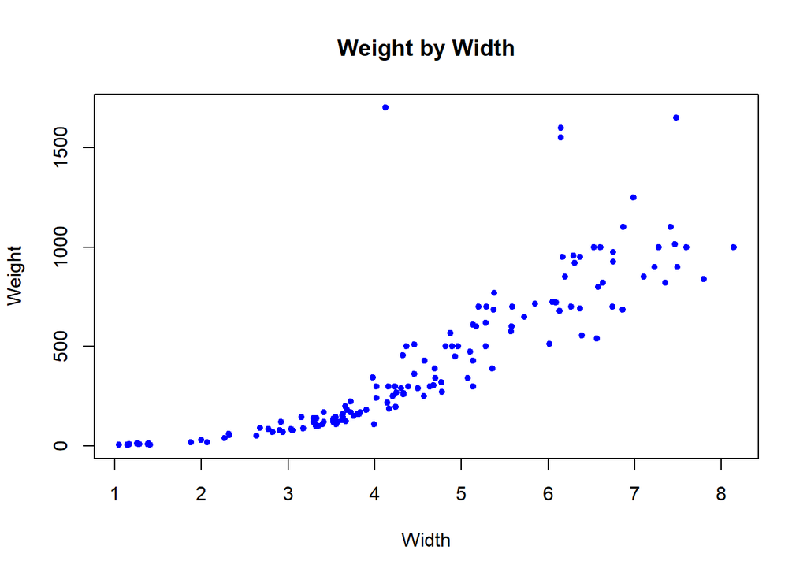

```r
plot(fish$Width,fish$Weight,
     xlab="Width",
     ylab="Weight",
     main="Weight by Width",
     col = "blue",
     pch=20)
```

**(c) Display the correlations between each of the variables. Interpret the correlations in the context of the relationships of the predictors to the response and in the context of multicollinearity.**

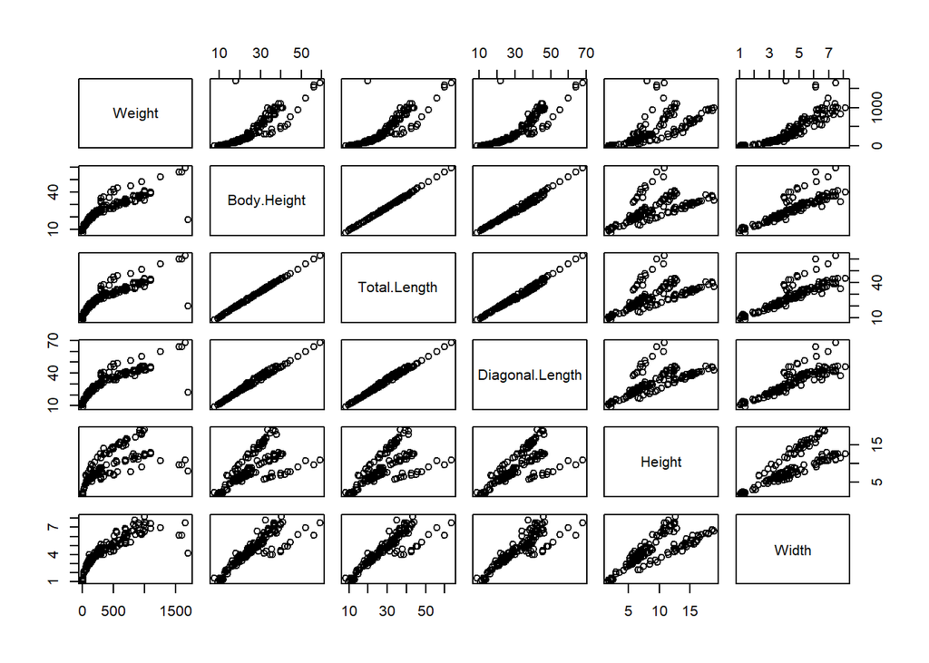

```r
par(mfrow = c(1, 1))
plot(fish[,-2])
```

```r
## Explore the correlation coefficients
round(cor(fish[,-2]), 2)
```

```
##                 Weight Body.Height Total.Length Diagonal.Length Height Width
## Weight            1.00        0.86         0.87            0.87   0.69  0.85
## Body.Height       0.86        1.00         1.00            0.99   0.63  0.87
## Total.Length      0.87        1.00         1.00            0.99   0.64  0.87
## Diagonal.Length   0.87        0.99         0.99            1.00   0.71  0.88
## Height            0.69        0.63         0.64            0.71   1.00  0.79
## Width             0.85        0.87         0.87            0.88   0.79  1.00
```

**Answer** **Relationships of the predictors to the response:** **Weight and body height** are strongly linearly correlated with a factor of 0.86 **Weight and total length**are strongly linearly correlated with a factor of 0.87 **Weight and diagonal length**are strongly linearly correlated with a factor of 0.87 **Weight and height**are neither weak nor strong linearly correlated, but somewhere in the middle with a correlation factor of 0.69 **Weight and width**are strongly linearly correlated with a factor of 0.85

**(d) Based on this exploratory analysis, is it reasonable to assume a multiple linear regression model for the relationship between *Weight* and the predictor variables?**

# Question 2: Fitting the Multiple Linear Regression Model [11 points]

*Create the full model without transforming the response variable or predicting variables using the fish data set. Do not use fishtest*

**(a) Build a multiple linear regression model, called model1, using the response and all predictors. Display the summary table of the model.**

```r
model1 = lm(Weight ~ ., fish)
summary(model1)
```

```
##
## Call:
## lm(formula = Weight ~ ., data = fish)
##
## Residuals:
##     Min      1Q  Median      3Q     Max
## -211.37  -70.59  -23.50   42.42 1335.87
##
## Coefficients:
##                  Estimate Std. Error t value Pr(>|t|)
## (Intercept)       -813.90     218.34  -3.728 0.000282 ***
## SpeciesParkki       79.34     132.71   0.598 0.550918
## SpeciesPerch        10.41     206.26   0.050 0.959837
## SpeciesPike         16.76     233.06   0.072 0.942775
## SpeciesRoach       194.03     156.84   1.237 0.218173
## SpeciesSmelt       455.78     204.92   2.224 0.027775 *
## SpeciesWhitefish    28.31     164.91   0.172 0.863967
## Body.Height       -176.87      61.36  -2.882 0.004583 **
## Total.Length       266.70      77.75   3.430 0.000797 ***
## Diagonal.Length    -72.49      49.48  -1.465 0.145267
## Height              38.27      22.09   1.732 0.085448 .
## Width               29.63      40.54   0.731 0.466080
## ---
## Signif. codes:  0 '***' 0.001 '**' 0.01 '*' 0.05 '.' 0.1 ' ' 1
##
## Residual standard error: 156.1 on 137 degrees of freedom
## Multiple R-squared:  0.8419, Adjusted R-squared:  0.8292
## F-statistic:  66.3 on 11 and 137 DF,  p-value: < 2.2e-16
```

**(b) Is the overall regression significant at an $\alpha$ level of 0.01?** Yes, the overall regression is significant because the p-value is < 2.2e-16, which is less than 0.01

# Question 3: Checking for Outliers and Multicollinearity [9 points]

**(a) Create a plot for the Cook’s Distances. Using a threshold Cook’s Distance of 1, identify the row numbers of any outliers.**

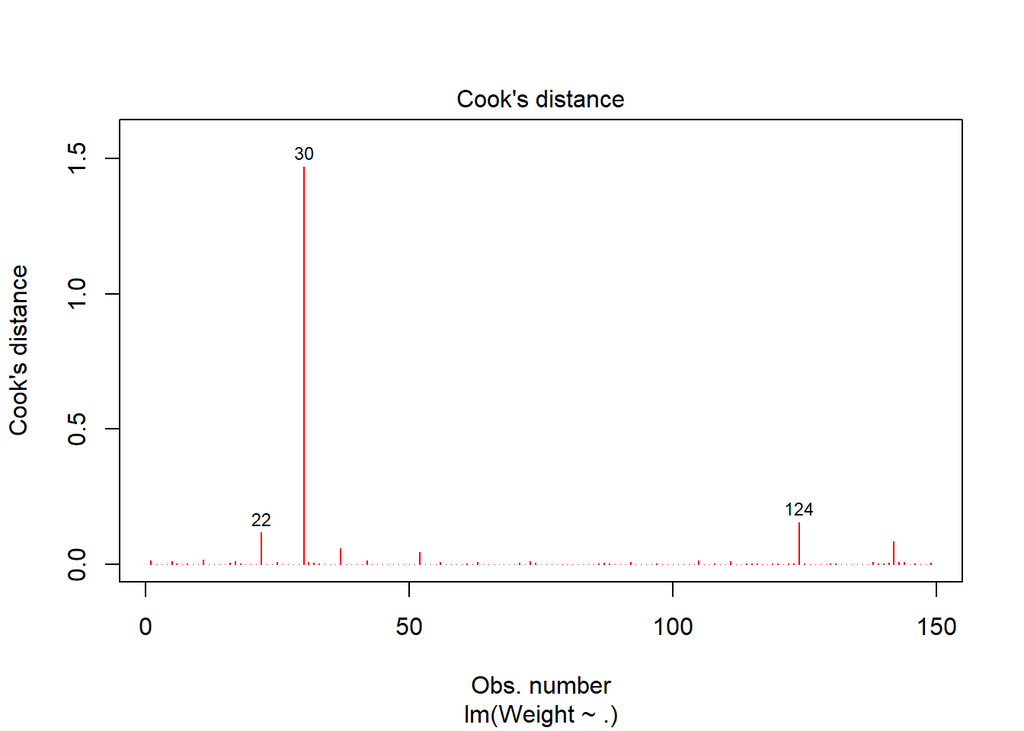

```r
#Identifying outliers with Cook's distance > 1
plot(model1, which =4, col="red")
```

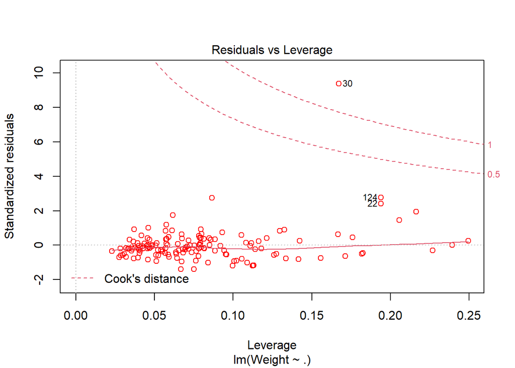

```r
plot(model1, which =5, col="red")
```

```r
fish[30,] # identifying the row
```

|  | Weight | Species | Body.Height | Total.Length | Diagonal.Length | Height | Width |
| --- | --- | --- | --- | --- | --- | --- | --- |
| 30 | 1700 | Roach | 18 | 20 | 22 | 8 | 4.1272 |

**(b) Remove the outlier(s) from the data set and create a new model, called model2, using all predictors with *Weight* as the response. Display the summary of this model.**

```r
#Removing influential points (Cooks distance >1)
fish_no_outlier = fish[-c(30), ]

#Fitting new model
model2 <- lm(Weight ~., fish_no_outlier)
summary(model2)
```

```
##
## Call:
## lm(formula = Weight ~ ., data = fish_no_outlier)
##
## Residuals:
##     Min      1Q  Median      3Q     Max
## -211.10  -50.18  -14.44   34.04  433.68
##
## Coefficients:
##                  Estimate Std. Error t value Pr(>|t|)
## (Intercept)      -969.766    131.601  -7.369 1.51e-11 ***
## SpeciesParkki     195.500     80.105   2.441 0.015951 *
## SpeciesPerch      174.241    124.404   1.401 0.163608
## SpeciesPike      -175.936    140.605  -1.251 0.212983
## SpeciesRoach      141.867     94.319   1.504 0.134871
## SpeciesSmelt      489.714    123.174   3.976 0.000113 ***
## SpeciesWhitefish  122.277     99.293   1.231 0.220270
## Body.Height       -76.321     37.437  -2.039 0.043422 *
## Total.Length       74.822     48.319   1.549 0.123825
## Diagonal.Length    34.349     30.518   1.126 0.262350
## Height             10.000     13.398   0.746 0.456692
## Width              -8.339     24.483  -0.341 0.733924
## ---
## Signif. codes:  0 '***' 0.001 '**' 0.01 '*' 0.05 '.' 0.1 ' ' 1
##
## Residual standard error: 93.84 on 136 degrees of freedom
## Multiple R-squared:  0.9385, Adjusted R-squared:  0.9335
## F-statistic: 188.6 on 11 and 136 DF,  p-value: < 2.2e-16
```

**(c) Display the VIF of each predictor for model2. Using a VIF threshold of max(10, 1/(1-$R^2$) what conclusions can you draw?**

```r
vif(model2)
```

```
##                       GVIF Df GVIF^(1/(2*Df))
## Species         1545.55017  6        1.843983
## Body.Height     2371.15420  1       48.694499
## Total.Length    4540.47698  1       67.383062
## Diagonal.Length 2126.64985  1       46.115614
## Height            56.21375  1        7.497583
## Width             29.01683  1        5.386727
```

# Question 4: Checking Model Assumptions [9 points]

*Please use the cleaned data set, which have the outlier(s) removed, and model2 for answering the following questions.*

**(a) Create scatterplots of the standardized residuals of model2 versus each quantitative predictor. Does the linearity assumption appear to hold for all predictors?**

```r
# LINEARITY ASSUMPTION

## Standardized Residuals versus individual predicting variables
library(MASS)
```

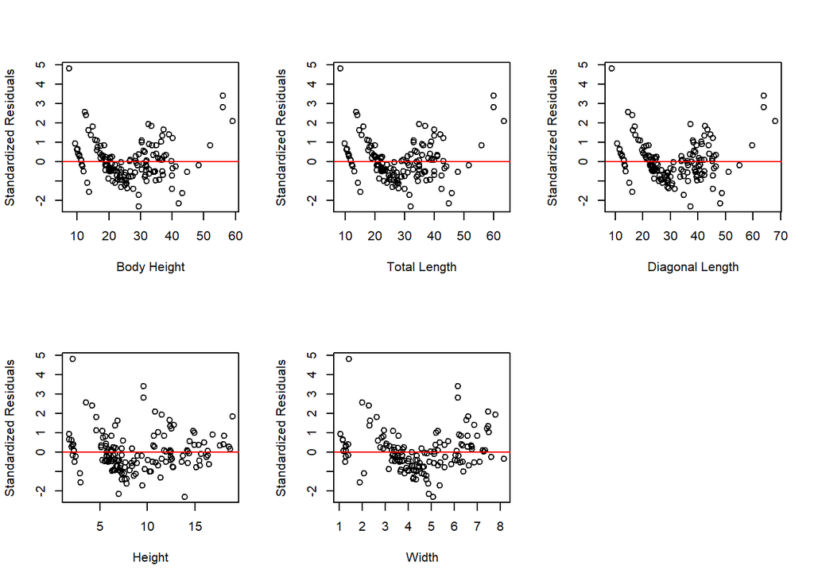

```r
resids_2 = stdres(model2)   # Create residuals


#Plotting
par(mfrow =c(2,3))
plot(fish_no_outlier[,3],resids_2,xlab="Body Height",ylab="Standardized Residuals")
abline(0,0,col="red")

plot(fish_no_outlier[,4],resids_2,xlab="Total Length",ylab="Standardized Residuals")
abline(0,0,col="red")

plot(fish_no_outlier[,5],resids_2,xlab="Diagonal Length",ylab="Standardized Residuals")
abline(0,0,col="red")

plot(fish_no_outlier[,6],resids_2,xlab="Height",ylab="Standardized Residuals")
abline(0,0,col="red")


plot(fish_no_outlier[,7],resids_2,xlab="Width",ylab="Standardized Residuals")
abline(0,0,col="red")
```

**(b) Create a scatter plot of the standardized residuals of model2 versus the fitted values of model2. Does the constant variance assumption appear to hold? Do the errors appear uncorrelated?**

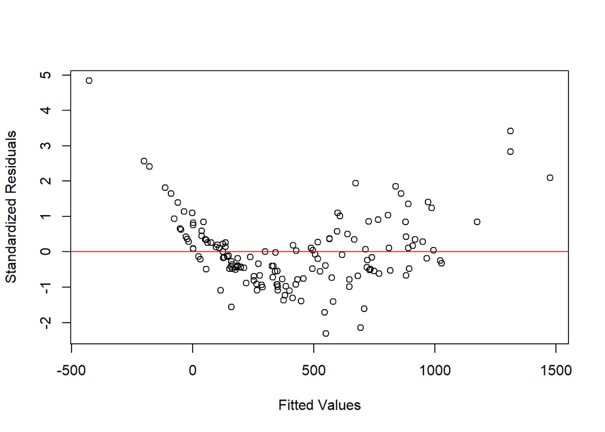

```r
# CONSTANT VARIANCE ASSUMPTION


## Standardized Residuals versus fitted values
fits_2 = model2$fitted   #Create fitted values


#Plotting
plot(fits_2, resids_2, xlab="Fitted Values",ylab="Standardized Residuals")
abline(0,0,col="red")
```

**(c) Create a histogram and normal QQ plot for the standardized residuals. What conclusions can you draw from these plots?**

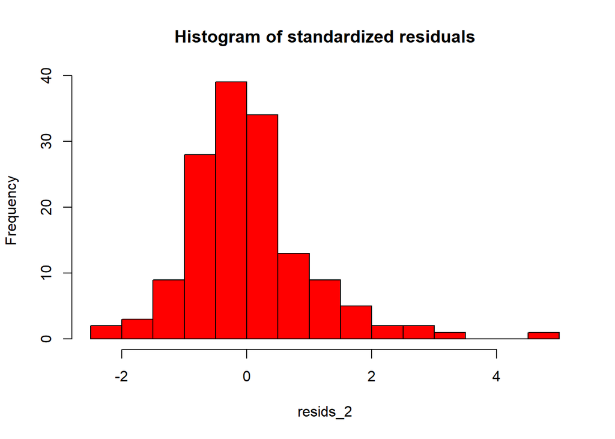

```r
# Histogram of residuals
hist(resids_2,nclass=20,col="red", border="black",main="Histogram of standardized residuals")
```

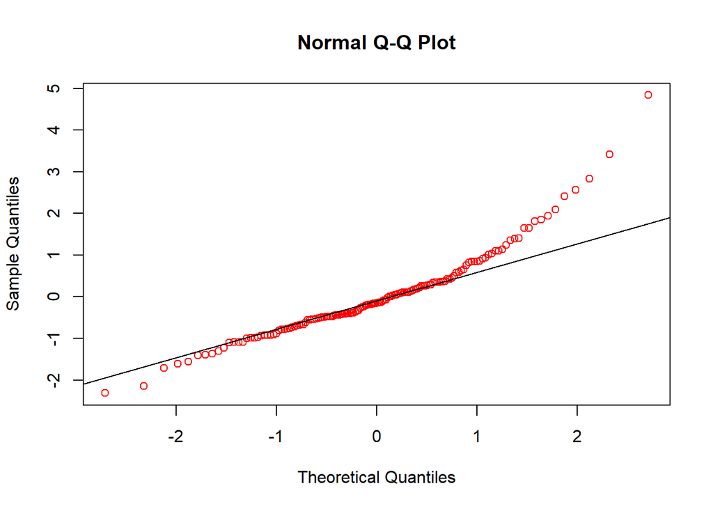

```r
#Q-Q plot of residuals
qqnorm(resids_2,col="red")
qqline(resids_2,col="black")
```

# Question 5 Partial F Test [6 points]

**(a) Build a third multiple linear regression model using the cleaned data set without the outlier(s), called model3, using only *Species* and *Total.Length* as predicting variables and *Weight* as the response. Display the summary table of the model3.**

```r
model3 = lm(Weight ~ Species + Total.Length ,fish_no_outlier)
summary(model3)
```

```
##
## Call:
## lm(formula = Weight ~ Species + Total.Length, data = fish_no_outlier)
##
## Residuals:
##     Min      1Q  Median      3Q     Max
## -233.83  -56.59  -10.13   34.58  418.30
##
## Coefficients:
##                  Estimate Std. Error t value Pr(>|t|)
## (Intercept)      -730.977     42.449 -17.220  < 2e-16 ***
## SpeciesParkki      63.129     38.889   1.623    0.107
## SpeciesPerch      -23.941     21.745  -1.101    0.273
## SpeciesPike      -400.964     33.350 -12.023  < 2e-16 ***
## SpeciesRoach      -19.876     30.111  -0.660    0.510
## SpeciesSmelt      256.408     39.858   6.433 1.85e-09 ***
## SpeciesWhitefish  -14.971     42.063  -0.356    0.722
## Total.Length       40.775      1.181  34.527  < 2e-16 ***
## ---
## Signif. codes:  0 '***' 0.001 '**' 0.01 '*' 0.05 '.' 0.1 ' ' 1
##
## Residual standard error: 94.86 on 140 degrees of freedom
## Multiple R-squared:  0.9353, Adjusted R-squared:  0.9321
## F-statistic: 289.1 on 7 and 140 DF,  p-value: < 2.2e-16
```

**(b) Conduct a partial F-test comparing model3 with model2. What can you conclude using an $\alpha$ level of 0.01?**

```r
anova(model3, model2)
```

|  | Res.Df | RSS | Df | Sum of Sq | F | Pr(>F) |
| --- | --- | --- | --- | --- | --- | --- |
| 1 | 140 | 1259746 | NA | NA | NA | NA |
| 2 | 136 | 1197659 | 4 | 62086.66 | 1.762561 | 0.1399744 |

# Question 6: Reduced Model Residual Analysis and Multicollinearity Test [10 points]

**(a) Conduct a multicollinearity test on model3. Comment on the multicollinearity in model3.**

```r
vif(model3)
```

```
##                  GVIF Df GVIF^(1/(2*Df))
## Species      2.654472  6        1.084755
## Total.Length 2.654472  1        1.629255
```

**(b) Conduct residual analysis for model3 (similar to Q4). Comment on each assumption and whether they hold.**

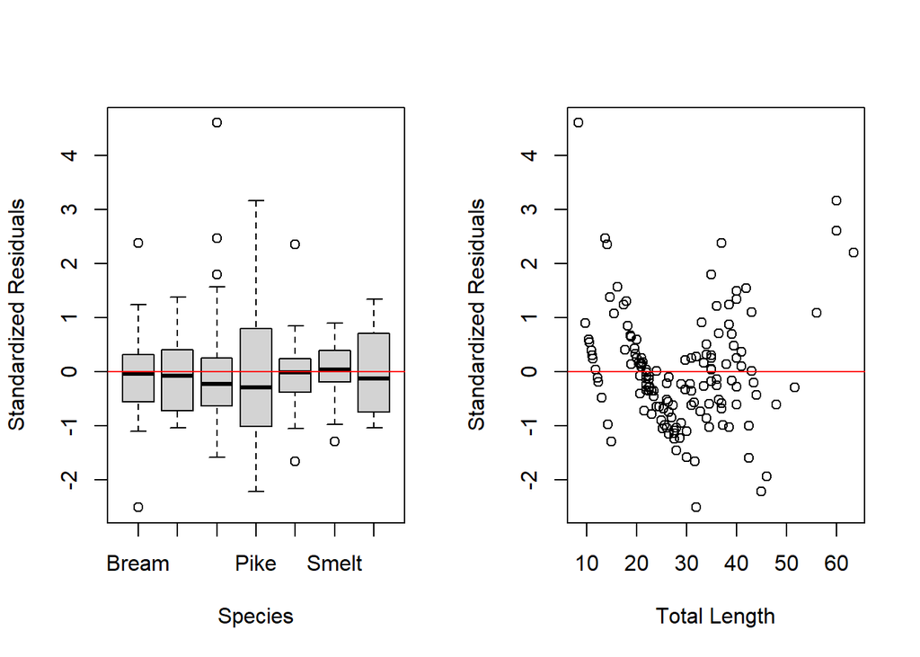

```r
# LINEARITY ASSUMPTION

## Standardized Residuals versus individual predicting variables
library(MASS)
resids_3 = stdres(model3)   # Create residuals

#Converting chr to categorical
fish_no_outlier$Species = as.factor(fish_no_outlier$Species)

#Plotting
par(mfrow =c(1,2))

plot(fish_no_outlier[,2],resids_3,xlab="Species",ylab="Standardized Residuals")
abline(0,0,col="red")

plot(fish_no_outlier[,4],resids_3,xlab="Total Length",ylab="Standardized Residuals")
abline(0,0,col="red")
```

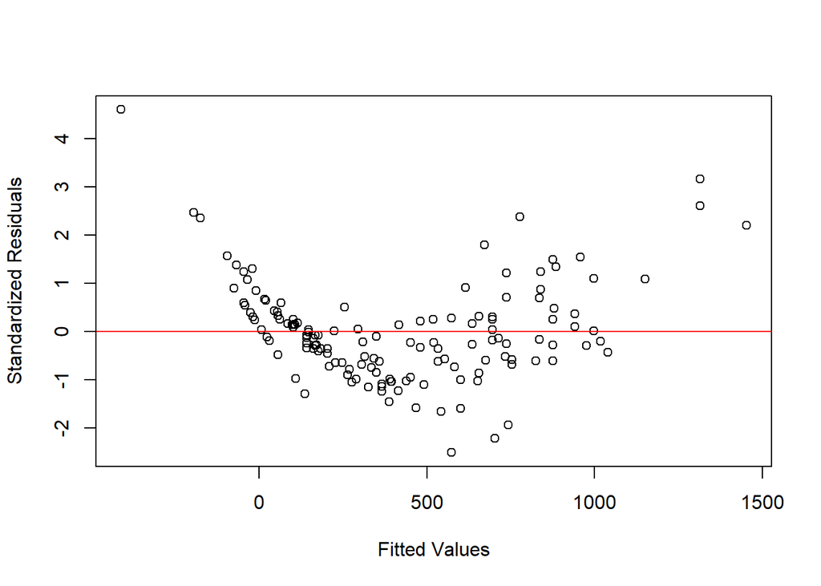

```r
# CONSTANT VARIANCE ASSUMPTION

## Standardized Residuals versus fitted values
fits_3 = model3$fitted   #Create fitted values

#Plotting
par(mfrow =c(1,1))
plot(fits_3, resids_3, xlab="Fitted Values",ylab="Standardized Residuals")
abline(0,0,col="red")
```

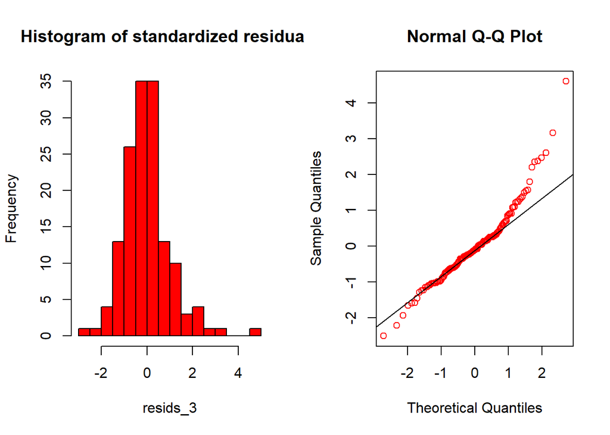

```r
#NORMMALITY

# Histogram of residuals
par(mfrow =c(1,2))
hist(resids_3,nclass=20,col="red", border="black",main="Histogram of standardized residuals")

#Q-Q plot of residuals
qqnorm(resids_3,col="red")
qqline(resids_3,col="black")
```

# Question 7: Transformation [12 pts]

**(a) Use model3 to find the optimal lambda, rounded to the nearest 0.5, for a Box-Cox transformation on model3. What transformation, if any, should be applied according to the lambda value? Please ensure you use model3**

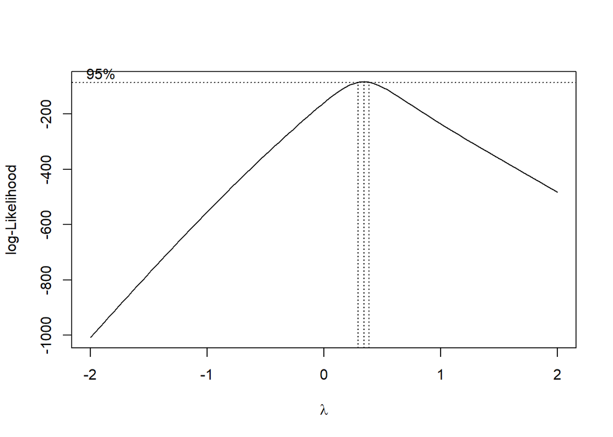

```r
bc <- boxcox(model3)
```

```r
lambda <- bc$x[which(bc$y==max(bc$y))]
lambda
```

```
## [1] 0.3434343
```

**(b) Based on the results in (a), create model4 with the appropriate transformation. Display the summary.**

```r
model4 = lm(sqrt(Weight) ~.,fish_no_outlier)
summary(model4)
```

```
##
## Call:
## lm(formula = sqrt(Weight) ~ ., data = fish_no_outlier)
##
## Residuals:
##     Min      1Q  Median      3Q     Max
## -4.4621 -0.6592 -0.0628  0.4951  3.3750
##
## Coefficients:
##                  Estimate Std. Error t value Pr(>|t|)
## (Intercept)      -11.0968     1.4985  -7.405 1.24e-11 ***
## SpeciesParkki      1.9759     0.9122   2.166 0.032040 *
## SpeciesPerch       2.5599     1.4166   1.807 0.072966 .
## SpeciesPike       -1.2251     1.6011  -0.765 0.445485
## SpeciesRoach       1.5944     1.0740   1.485 0.139981
## SpeciesSmelt       4.2163     1.4026   3.006 0.003152 **
## SpeciesWhitefish   2.7222     1.1307   2.408 0.017399 *
## Body.Height        0.2313     0.4263   0.543 0.588230
## Total.Length      -0.1049     0.5502  -0.191 0.849059
## Diagonal.Length    0.4955     0.3475   1.426 0.156182
## Height             0.5529     0.1526   3.624 0.000409 ***
## Width              0.8586     0.2788   3.080 0.002506 **
## ---
## Signif. codes:  0 '***' 0.001 '**' 0.01 '*' 0.05 '.' 0.1 ' ' 1
##
## Residual standard error: 1.069 on 136 degrees of freedom
## Multiple R-squared:  0.9876, Adjusted R-squared:  0.9866
## F-statistic: 986.3 on 11 and 136 DF,  p-value: < 2.2e-16
```

**(c) Perform Residual Analysis on model4. Comment on each assumption. Was the transformation successful/unsuccessful?**

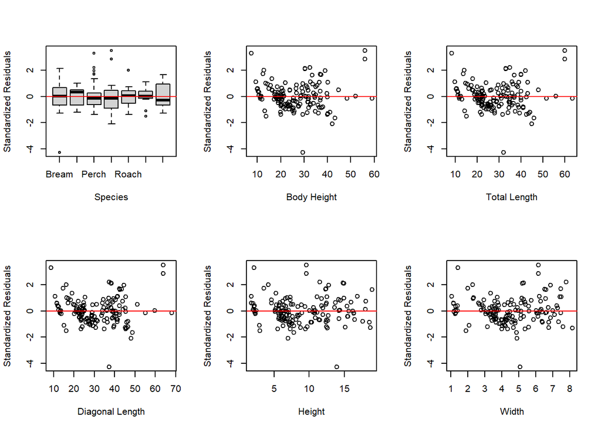

```r
# LINEARITY ASSUMPTION

## Standardized Residuals versus individual predicting variables
library(MASS)
resids_4 = stdres(model4)   # Create residuals


#Plotting
par(mfrow =c(2,3))

plot(fish_no_outlier[,2],resids_4,xlab="Species",ylab="Standardized Residuals")
abline(0,0,col="red")

plot(fish_no_outlier[,3],resids_4,xlab="Body Height",ylab="Standardized Residuals")
abline(0,0,col="red")

plot(fish_no_outlier[,4],resids_4,xlab="Total Length",ylab="Standardized Residuals")
abline(0,0,col="red")

plot(fish_no_outlier[,5],resids_4,xlab="Diagonal Length",ylab="Standardized Residuals")
abline(0,0,col="red")

plot(fish_no_outlier[,6],resids_4,xlab="Height",ylab="Standardized Residuals")
abline(0,0,col="red")

plot(fish_no_outlier[,7],resids_4,xlab="Width",ylab="Standardized Residuals")
abline(0,0,col="red")
```

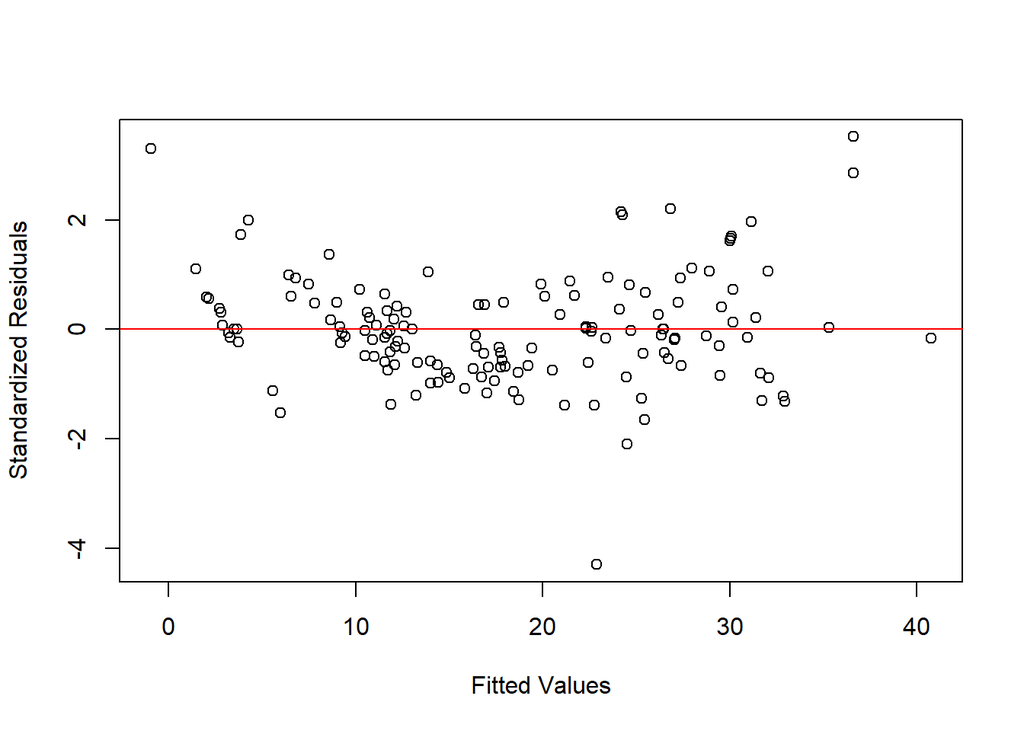

```r
# CONSTANT VARIANCE ASSUMPTION

## Standardized Residuals versus fitted values
fits_4 = model4$fitted   #Create fitted values

#Plotting
par(mfrow =c(1,1))
plot(fits_4, resids_4, xlab="Fitted Values",ylab="Standardized Residuals")
abline(0,0,col="red")
```

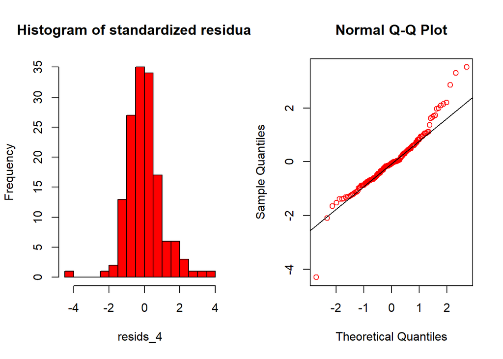

```r
#NORMMALITY

# Histogram of residuals
par(mfrow =c(1,2))
hist(resids_4,nclass=20,col="red", border="black",main="Histogram of standardized residuals")

#Q-Q plot of residuals
qqnorm(resids_4,col="red")
qqline(resids_4,col="black")
```

# Question 8: Model Comparison [3pts]

**(a) Using each model summary, compare and discuss the R-squared and Adjusted R-squared of model2, model3, and model4.**

# Question 9: Estimation and Prediction [10 points]

**(a) Estimate Weight for the last 10 rows of data (fishtest) using both model3 and model4. Compare and discuss the mean squared prediction error (MSPE) of both models.**

**(b) Suppose you have found a Perch fish with a Body.Height of 28 cm, and a Total.Length of 32 cm. Using model4, predict the weight on this fish with a 90% prediction interval. Provide an interpretation of the prediction interval.**